# RMarkdown

Maria Cuellar

2025-09-16

# Introduction

R Markdown lets you **combine code, output, and text** in the same document. You can write your analysis, include plots, and explain your results — all in one file — and render it into an HTML, PDF, or Word report.

This guide will help you:

1. Understand the basic structure of an `.Rmd` file
2. Write text using **Markdown** formatting
3. Add and run R code chunks
4. Render the document to HTML

# R Markdown Structure

An R Markdown file has three parts:

1. **YAML header** – appears at the top between `---` lines (title, author, etc.)
2. **Markdown text** – regular writing with formatting
3. **Code chunks** – blocks of R code surrounded by three backticks

# Writing Text with Markdown

You can write *italic*, **bold**, and even lists:

- Item 1
- Item 2
- Item 3

You can also add links:

```
 [Visit RStudio's R Markdown site](https://rmarkdown.rstudio.com)
```

[Visit RStudio’s R Markdown site](https://rmarkdown.rstudio.com)

And equations:

```
 `$E = mc^2$` → \(E = mc^2\)
```

`$E = mc^2$` → $E = mc^2$

# Code Chunks

To include R code, use a **code chunk** using this syntax:

````
 ```{r}  x <- 5 x + 10 ```
````

Ends up looking like this:

```r
# A simple calculation
x <- 5
y <- 10
x + y
```

```
## [1] 15
```

# Adding Plots

Plots can be added using the same ‘chunk’ syntax:

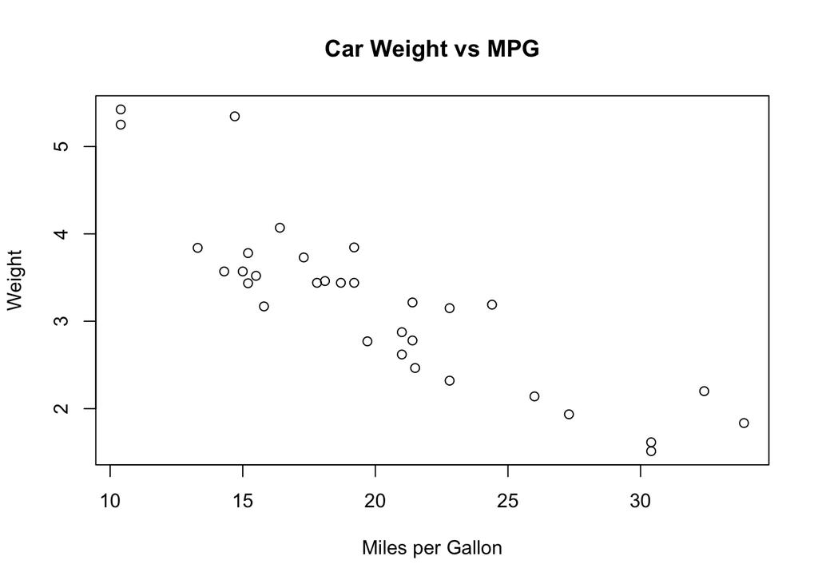

```r
# Make a simple scatterplot
plot(mtcars$mpg, mtcars$wt,
     xlab = "Miles per Gallon",
     ylab = "Weight",
     main = "Car Weight vs MPG")
```

# Chunk Options

You can control what appears in your report with chunk options in with the {r} curly braces: e.g.,

````
 ```{r, echo=FALSE, eval=FALSE}  x <- 5 x + 10 ```
````

:

- echo=FALSE → hide code, show results
- eval=FALSE → show code, but don’t run it
- message=FALSE, warning=FALSE → hide messages/warnings

# Rendering Your Document

Click Knit in RStudio and choose Knit to HTML.

R will:

- Run all the code chunks
- Combine them with your text
- Produce a clean, shareable report

# Tips for Success:

- Save your .Rmd file often.
- Knit regularly to catch errors early.
- Use clear headings (#, ##, ###) to organize your report.
- Keep code readable: use comments (#) to explain what it does.
- Load the libraries you need at the beginning of the document. Don’t try to use an object you haven’t defined earlier in the document. Rmd runs the R code from the beginning of the file to the end, so if the library or object haven’t been defined, the Rmd file won’t run.
- Don’t install.packages or use `View(data)` in Rmd files.